# Statistical Methods for Insurance: Fitting Models

W4.C1

## Overview of this class

- Quiz 2
- Fit distribution for olympic medals

## Olympic medals, 2012 London

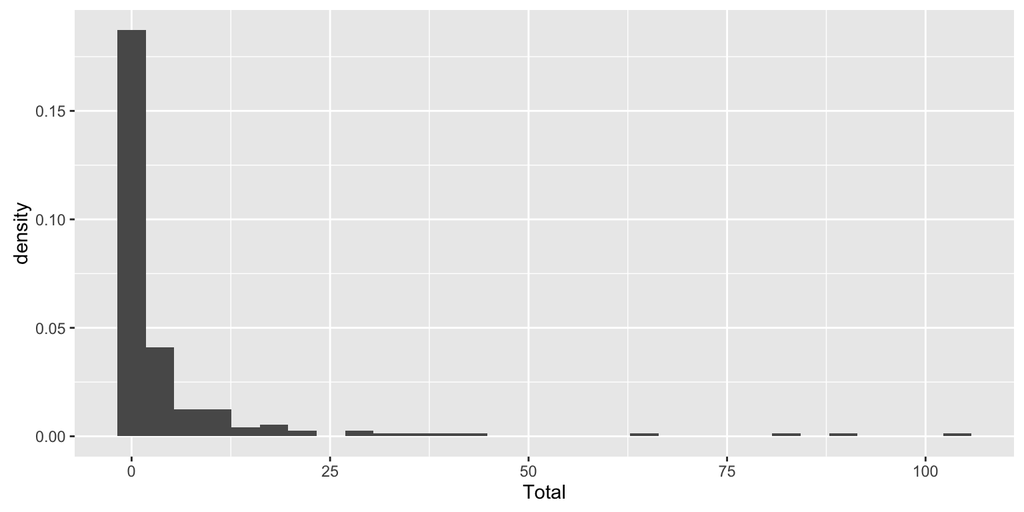

## Data

- Extracted from https://www.olympic.org/london-2012
- Now it is easier to pull data from [wikipedia](https://en.wikipedia.org/wiki/2012_Summer_Olympics_medal_table)
- 204 countries participated, only countries that scored a medal (85) are listed in the medal table

## Medal tally

- Examine the distribution of medal counts
- Need to add 119 zeros, to account for participating countries that did not get a medal
- Distribution is right-skewed, heavily, and unimodal
- Use maximum likelihood to estimate parameters for plausible distributions

## Fit distribution using Poisson

```
#>   lambda
#>   4.72
#>  (0.15)
```

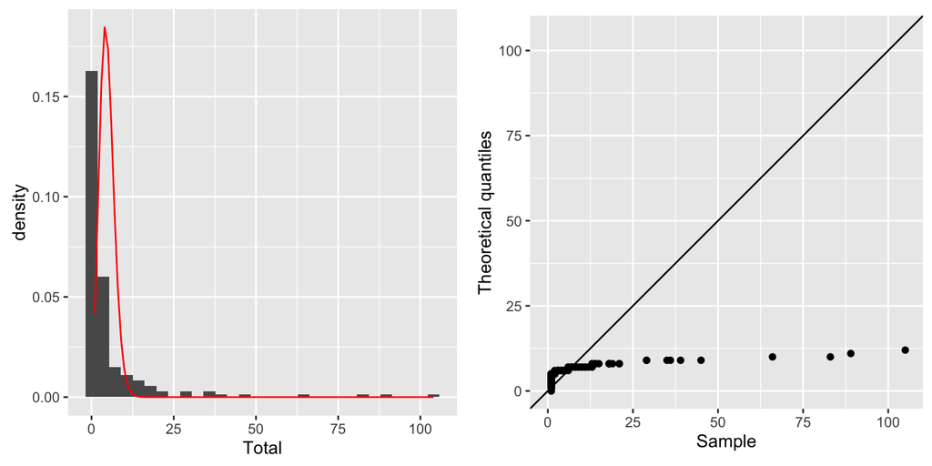

## Try lognormal

```
#>   meanlog    sdlog
#>   0.779     1.137
#>  (0.080)   (0.056)
```

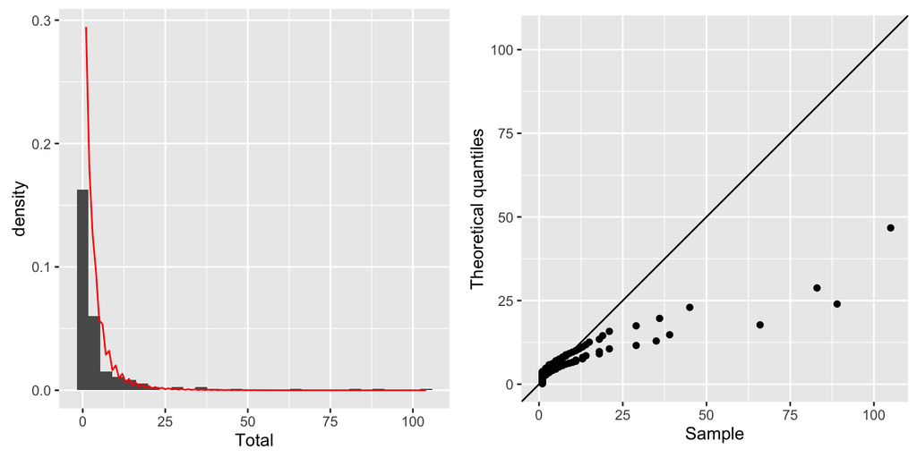

## Try weibull

```
#>    shape    scale
#>   0.707    4.106
#>  (0.033)  (0.434)
```

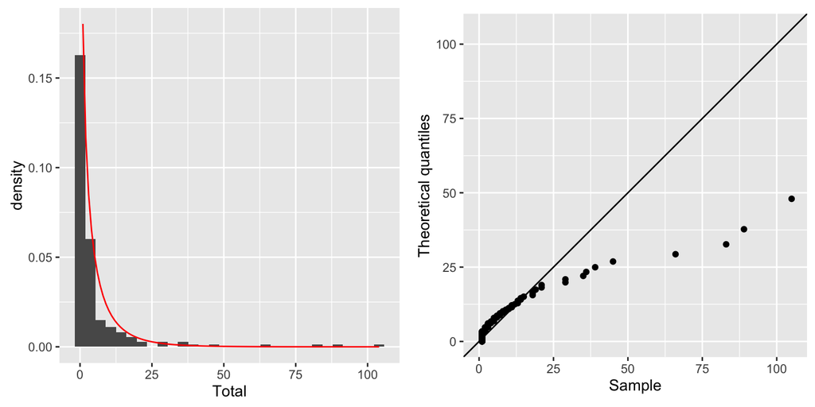

## Try pareto

[output not shown]

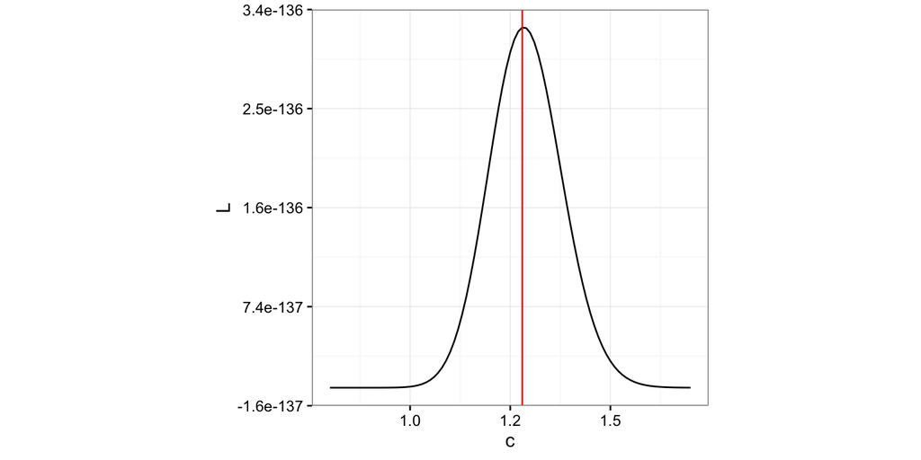

## Optimization actually fails

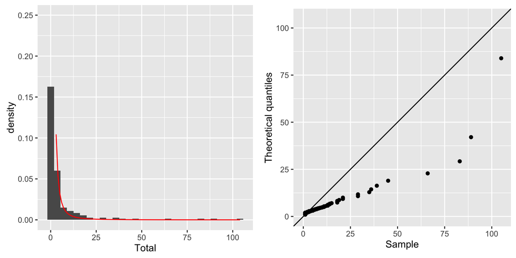

## Manually

Actually using \(c=0.96\).

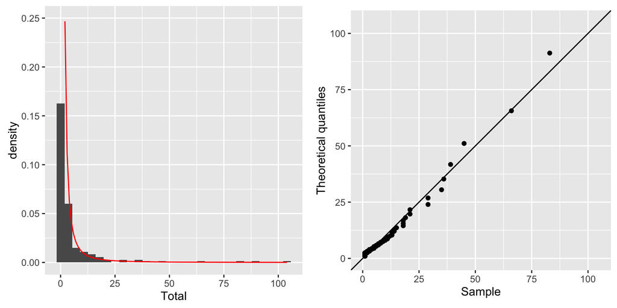

## Predict largest medal count

Using this model, what is the probability of observing a tally of more than 50 medals for a country? \(P(X>50)\)

```r
ppareto <- function(q, c) {
  if (c<=0) stop("c must be positive > 0")
  ifelse(q<1, 0, 1-1/q^c)
}
1-ppareto(50, 0.96)
```

```
#> [1] 0.023
```

## How many would we expect?

If there are 204 countries, how many of them would we expect to earn more than 50 medals, assuming the \(Pareto(0.96)\) model?

```r
204*(1-ppareto(50, 0.96))
```

```
#> [1] 4.8
```

and how does this compare to the observed number?

```r
library(dplyr)
df %>% filter(Total>50)
```

```
#>   Total
#> 1    65
#> 2    82
#> 3    88
#> 4   104
```

## How well does this fit 2008 medal tally?

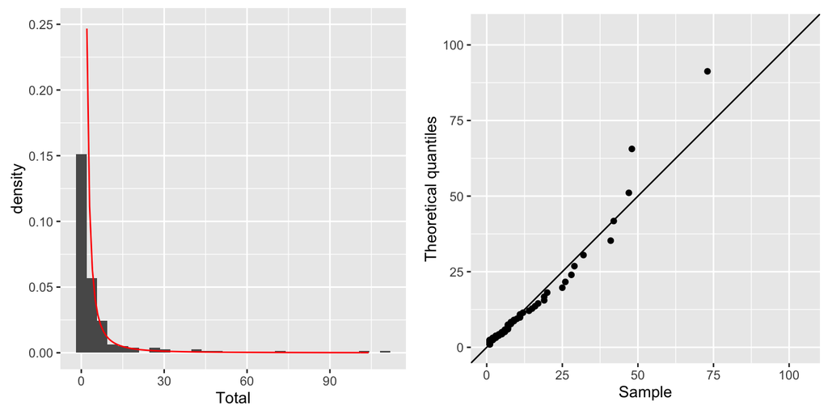

## And 2004?

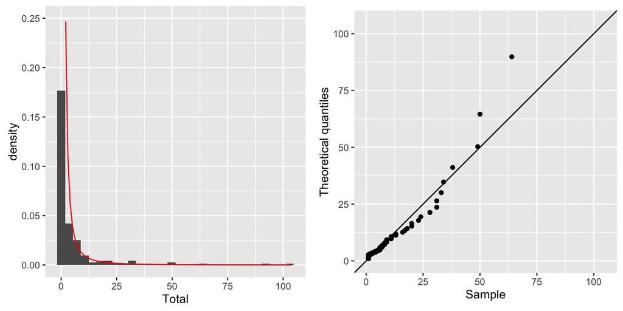

## Doping in sports - finding anomalies

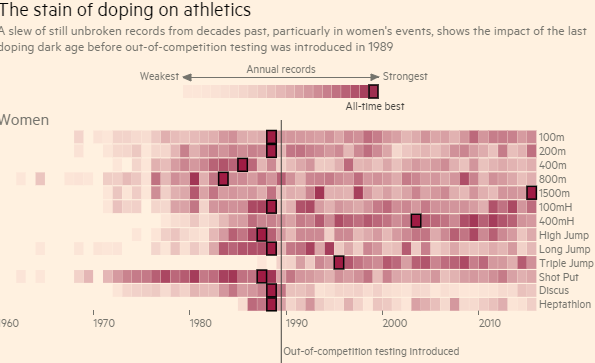

Source: FT research, image extracted from http://blogs.ft.com/ftdata/2015/11/16/doping-in-athletics/

## YOUR TURN: How could we improve the model?

- What dependencies are there in the medal tallies?
- What varies among Olympic years?
- What factors might affect the medal counts?

## Resources

- [2012 Medal tally](https://en.wikipedia.org/wiki/2012_Summer_Olympics_medal_table)
- [2008 Medal tally](https://en.wikipedia.org/wiki/2008_Summer_Olympics_medal_table)
- [2004 Medal tally](https://en.wikipedia.org/wiki/2004_Summer_Olympics_medal_table)
- http://blogs.ft.com/ftdata/2015/11/16/doping-in-athletics/

## Share and share alike

This work is licensed under the Creative Commons Attribution-Noncommercial 3.0 United States License. To view a copy of this license, visit http://creativecommons.org/licenses/by-nc/ 3.0/us/ or send a letter to Creative Commons, 171 Second Street, Suite 300, San Francisco, California, 94105, USA.